# Stroop Effect

### Q1. What is our independent variable? What is our dependent variable?

Answer:

The dependent variable is time spend in test.

Other variables, such as size of word, time of experiement taken, color of the ink, are independent variable

### Q2. What is an appropriate set of hypotheses for this task? What kind of statistical test do you expect to perform? Justify your choices.

Answer:

From the experience of playing 'Interactive Stroop Effect Experiment' game, it is reasonable to think of that,it is harder to name a word correctly in incongruent condition than in congrunent condition. Thus the hypotheses are:

**Null hypotheses:** The average responding time in congruent condition is **not significant different** from average responding time in incongruent condition.

H<sub>o</sub>: µt(cong) = µt(incong)

**Alt hypotheses:** The average responding time in congruent condition is **less than** average responding time in incongruent condition.

H<sub>A</sub>: µt(cong) < µt(incong)

Based on the hypotheses,we could perform hypothesis testing, with one-tail dependent t test.

We using one-tail test because the hypothesis assume average responding time of incongruent condistion is bigger than congruent condition. Further, the one-tail test should be on negative direction.

Performing t test rather than z test because t test is more apropirate for small samples.

# Q3. Report some descriptive statistics regarding this dataset. Include at least one measure of central tendency and at least one measure of variability.

```python
import pandas as pd
import matplotlib.pyplot as plt
data = pd.read_csv("stroopdata.csv")
data.describe()
```

|  | Congruent | Incongruent |
| --- | --- | --- |
| count | 24.000000 | 24.000000 |
| mean | 14.051125 | 22.015917 |
| std | 3.559358 | 4.797057 |
| min | 8.630000 | 15.687000 |
| 25% | 11.895250 | 18.716750 |
| 50% | 14.356500 | 21.017500 |
| 75% | 16.200750 | 24.051500 |
| max | 22.328000 | 35.255000 |

# Q4. Provide one or two visualizations that show the distribution of the sample data. Write one or two sentences noting what you observe about the plot or plots.

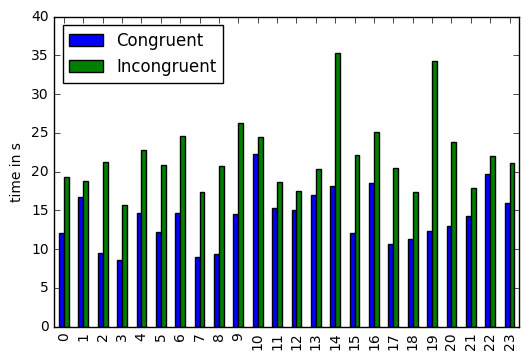

```python
%pylab inline
data.plot.bar()
plt.ylabel("time in s")
```

From the plot we could clearly see that in this sample people spend more time in incongruent condition than in congruent condition.

# Q5. Now, perform the statistical test and report your results. What is your confidence level and your critical statistic value? Do you reject the null hypothesis or fail to reject it? Come to a conclusion in terms of the experiment task. Did the results match up with your expectations?

```python
# number of count
count  = data["Congruent"].count()
print "number of count:",count
# degree of freedom
print "degree of freedom:",data["Congruent"].count() -1
# t-critical when alpha level equals .05, note this test is single-tail:
critical = -1.714
print "t-critical value when alpha level equals .05:", critical
#mean and std of difference:
data["Difference"] = data["Congruent"] - data["Incongruent"]
mean = data['Difference'].mean()
std = data['Difference'].std()
print "mean of difference:",mean
print "standard diviation of difference:",std
# t-statistic
sem = std/sqrt(count)
print "standard error mean:",sem
print "t statistic value:", mean/sem
merror = sem*critical
print "margin of error:", merror
print "95% confident interval:(",mean - merror, mean + merror,")"
```

```
number of count: 24
degree of freedom: 23
t-critical value when alpha level equals .05: -1.714
mean of difference: -7.96479166667
standard diviation of difference: 4.86482691036
standard error mean: 0.993028634778
t statistic value: -8.02070694411
margin of error: -1.70205108001
95% confident interval:( -6.26274058666 -9.66684274668 )
```